# Lab 03 – Data Analysis

Melissa Juarez

February 21, 2022

#### Q1: Run a simple bivariate regression, and interpret your results. (Did the results fit your expectations? Why? Why not?)

For this question, I will look at the relationship between hours worked (`hrs1`) and stress in the workplace (`stress`). `hrs1` is a semi-continuous variable, taking integer numbers on the real line. `stress` is a categorical variable that answers the question: How often do you find work stressful? It is coded from (1) always to (5) never. As the stress number code increases, we read that to mean that a person’s work stress is decreasing. I expect that as a person works more hours, their points associated with the `stress` variable with decrease. This means that they lean more towards the beginning of the spectrum that indicates higher stress levels.

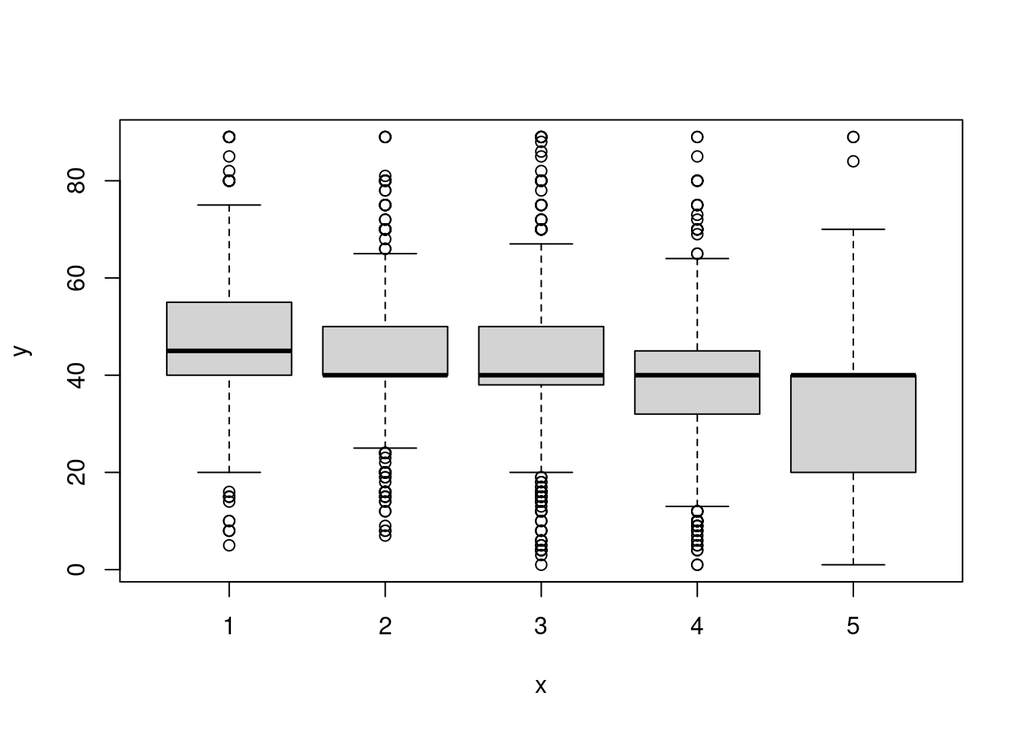

```r
plot(as.factor(gss$stress), gss$hrs1)
```

```r
m1 <- lm(stress ~ hrs1, data = gss)
summary(m1)
```

```
##
## Call:
## lm(formula = stress ~ hrs1, data = gss)
##
## Residuals:
##     Min      1Q  Median      3Q     Max
## -2.4573 -0.7775  0.1375  0.4774  2.9703
##
## Coefficients:
##              Estimate Std. Error t value Pr(>|t|)
## (Intercept)  3.542290   0.062944   56.28   <2e-16 ***
## hrs1        -0.016996   0.001412  -12.03   <2e-16 ***
## ---
## Signif. codes:  0 '***' 0.001 '**' 0.01 '*' 0.05 '.' 0.1 ' ' 1
##
## Residual standard error: 1.032 on 2609 degrees of freedom
##   (1899 observations deleted due to missingness)
## Multiple R-squared:  0.05258,    Adjusted R-squared:  0.05222
## F-statistic: 144.8 on 1 and 2609 DF,  p-value: < 2.2e-16
```

In our linear model above, we see that a 1 hour increase of hours worked in the week, respondents is expected to find a 0.0170 points decrease in finding their job as less stressful. In other words, they are more likely to find their job more stressful by 0.0170 points. This model fit my expectations, although the explained variation of `stress` from `hrs1` is lower than I thought it would be, at 5.2%.

#### Q2: Add an additional variable that might mediate or partly “explain” the initial association from that simple regression above – and explain your results. Did it work out? Yes? No?

I am choosing to consider `famvswk` as a mediator variable. `famvswk` is categorical variable that relating to the question: How often do the demands of your family interfere with your work on the job? The categories range from (1) Often to (4) Never. As the `famvswk` number code increases, we read that to mean that a person’s family life decreasingly interferes with their work.

I chose this as a mediator variable given that it’s possible that as a person has more work hours, they have less time to meet their family responsibilities causing family-work tensions; this might partially explain the association between hours worked and work stress. The model below adds `famvswk` to our existing linear model from part 1.

```r
m2 <- lm(stress ~ hrs1 + famvswk, data = gss)
summary(m2)
```

```
##
## Call:
## lm(formula = stress ~ hrs1 + famvswk, data = gss)
##
## Residuals:
##      Min       1Q   Median       3Q      Max
## -2.62007 -0.71851  0.08107  0.59203  2.65403
##
## Coefficients:
##             Estimate Std. Error t value Pr(>|t|)
## (Intercept)  2.94358    0.11696  25.167  < 2e-16 ***
## hrs1        -0.01565    0.00165  -9.483  < 2e-16 ***
## famvswk      0.20042    0.02882   6.954  5.1e-12 ***
## ---
## Signif. codes:  0 '***' 0.001 '**' 0.01 '*' 0.05 '.' 0.1 ' ' 1
##
## Residual standard error: 0.9938 on 1655 degrees of freedom
##   (2852 observations deleted due to missingness)
## Multiple R-squared:  0.08219,    Adjusted R-squared:  0.08108
## F-statistic:  74.1 on 2 and 1655 DF,  p-value: < 2.2e-16
```

Hours worked held constant, we see that for a one category increase on a scale of (1) Often to (4) Never in the `famvswk` variable, respondents are expected to be 0.200 points higher on finding work less stressful. In other words, as people find balance in their work and home life (i.o.w `famvswk` variable increases), their work stress decreases (i.o.w `stress` variable increases).

```r
## x -> m
summary(lm(famvswk ~ hrs1, data = gss))
```

```
##
## Call:
## lm(formula = famvswk ~ hrs1, data = gss)
##
## Residuals:
##      Min       1Q   Median       3Q      Max
## -2.15090 -0.93674  0.00027  0.96668  1.20604
##
## Coefficients:
##              Estimate Std. Error t value Pr(>|t|)
## (Intercept)  3.167699   0.062594  50.607   <2e-16 ***
## hrs1        -0.004199   0.001403  -2.994   0.0028 **
## ---
## Signif. codes:  0 '***' 0.001 '**' 0.01 '*' 0.05 '.' 0.1 ' ' 1
##
## Residual standard error: 0.8485 on 1659 degrees of freedom
##   (2849 observations deleted due to missingness)
## Multiple R-squared:  0.005374,   Adjusted R-squared:  0.004774
## F-statistic: 8.963 on 1 and 1659 DF,  p-value: 0.002795
```

```r
## m -> y
summary(lm(stress ~ hrs1, data = gss))
```

```
##
## Call:
## lm(formula = stress ~ hrs1, data = gss)
##
## Residuals:
##     Min      1Q  Median      3Q     Max
## -2.4573 -0.7775  0.1375  0.4774  2.9703
##
## Coefficients:
##              Estimate Std. Error t value Pr(>|t|)
## (Intercept)  3.542290   0.062944   56.28   <2e-16 ***
## hrs1        -0.016996   0.001412  -12.03   <2e-16 ***
## ---
## Signif. codes:  0 '***' 0.001 '**' 0.01 '*' 0.05 '.' 0.1 ' ' 1
##
## Residual standard error: 1.032 on 2609 degrees of freedom
##   (1899 observations deleted due to missingness)
## Multiple R-squared:  0.05258,    Adjusted R-squared:  0.05222
## F-statistic: 144.8 on 1 and 2609 DF,  p-value: < 2.2e-16
```

#### Q3: Run another multiple regression. Tell me how you expect your dependent variable to be affected by the independent variables. Interpret your results.

I expect that when sex is held constant, as education levels increase, income attitudes will decrease meaning that attitudes shift towards supporting income equality. I also expect that when education is held constant, females will have attitudes with lower points (attitudes towards supporting income equality) than males. I expect that those belonging to higher income groups will be in higher favor of larger income gaps, as they are probably expected to benefit from them.

Additionally, I will only be looking at responses from the United States.

```r
## multiple regression model & summary looking only at the US

## Note: I will also drop any rows with missign values in my variables of interest so that in the anova.
## I don't get an error & my 2 models use the same data.

us_wvs <- wvs %>%
  filter(V2 == 840) %>% ## US country code
  dplyr::rename(c(incomeattitude = V96,
         educ = V188,
         sex = V240, ## 1 is male (base), 2 is female
         incmgrp = V239,
         religion = V9
  )) %>%
  select(incomeattitude, educ, sex, incmgrp, religion) %>%
  na.omit()

us_wvs$sex <- as.factor(us_wvs$sex)
m3 <- lm(incomeattitude ~ sex + educ + incmgrp , data = us_wvs)
summary(m3)
```

```
##
## Call:
## lm(formula = incomeattitude ~ sex + educ + incmgrp, data = us_wvs)
##
## Residuals:
##    Min     1Q Median     3Q    Max
## -5.562 -1.779  0.097  1.873  5.573
##
## Coefficients:
##             Estimate Std. Error t value Pr(>|t|)
## (Intercept)  4.47945    0.30217  14.824  < 2e-16 ***
## sex2        -0.31600    0.10885  -2.903  0.00373 **
## educ         0.09162    0.08033   1.141  0.25416
## incmgrp      0.17164    0.02971   5.777 8.73e-09 ***
## ---
## Signif. codes:  0 '***' 0.001 '**' 0.01 '*' 0.05 '.' 0.1 ' ' 1
##
## Residual standard error: 2.512 on 2130 degrees of freedom
## Multiple R-squared:  0.02343,    Adjusted R-squared:  0.02205
## F-statistic: 17.03 on 3 and 2130 DF,  p-value: 6.241e-11
```

In the output above, we have the estimated model $incomeattitude = 4.479 - 0.316sex_{female} + 0.092educ + 0.172incmgrp$. We can interpret it as follows:

- Education & income group held constant, when sex == female (coded as 2), there is an expected 0.316 decrease in income attitudes, supporting in the direction of more equal income.
- Sex & income group held constant, for an increase in 1 level of education, there is an expected 0.092 increase in income attitudes, supporting in the direction of large income differences. This differs from what I expected. *However, this is not an significant relationship.*
- Educ & sex held constant, for an increase in 1 income group level, there is an expected 0.172 increase in income attitudes, supporting in the direction of large income differences.

#### Q4: Now add another independent variable to that model in Question 3, preferably a set of dummy variables. Tell me why you added that new set of variables and what effect you expected them to have. Did they have an effect? Interpret that new model.

I am adding the variable `religion`/`V9`, indication how important religion is to the respondent from (1) Very important to (4) Not at all important. I expect that as religion becomes less important, income attitude points will increase indicating a support towards income gaps.

```r
m4 <- lm(incomeattitude ~ sex + educ + incmgrp + religion, data = us_wvs)
summary(m4)
```

```
##
## Call:
## lm(formula = incomeattitude ~ sex + educ + incmgrp + religion,
##     data = us_wvs)
##
## Residuals:
##     Min      1Q  Median      3Q     Max
## -5.7970 -1.7140  0.0706  1.8441  5.8598
##
## Coefficients:
##             Estimate Std. Error t value Pr(>|t|)
## (Intercept)  4.94793    0.31203  15.857  < 2e-16 ***
## sex2        -0.37704    0.10868  -3.469 0.000532 ***
## educ         0.12270    0.07998   1.534 0.125152
## incmgrp      0.17652    0.02952   5.979 2.63e-09 ***
## religion    -0.28422    0.05178  -5.489 4.53e-08 ***
## ---
## Signif. codes:  0 '***' 0.001 '**' 0.01 '*' 0.05 '.' 0.1 ' ' 1
##
## Residual standard error: 2.495 on 2129 degrees of freedom
## Multiple R-squared:  0.03705,    Adjusted R-squared:  0.03524
## F-statistic: 20.48 on 4 and 2129 DF,  p-value: < 2.2e-16
```

In the output above, we have the estimated model $incomeattitude = 4.95 - 0.377sex_{female} + 0.123educ + 0.177incmgrp - 0.284religion$. We can interpret it as follows:

- Educ, sex, and income group held constant, for a 1 level increase in religion (indicating lower religious importance), we expect a 0.284 decrease in income attitudes in support of income equality. This is different from what I expected, and perhaps this may be because an increase in religious important might reflect conservative attitudes?
- Education, religion, & income group held constant, when sex == female (coded as 2), there is an expected 0.377 decrease in income attitudes, supporting in the direction of more equal income.
- Sex, religion, & income group held constant, for an increase in 1 level of education, there is an expected 0.123 increase in income attitudes, supporting in the direction of large income differences. This differs from what I expected. *However, this is still not an significant relationship.*
- Educ,religion, & sex held constant, for an increase in 1 income group level, there is an expected 0.177 increase in income attitudes, supporting in the direction of large income differences.

#### Q5: Now run a partial F test comparing the model in Question 3 to the model in Question 4. Does the F test support the idea of adding those new variables? Why? Why not?

```r
anova(m3, m4)
```

```
## Analysis of Variance Table
##
## Model 1: incomeattitude ~ sex + educ + incmgrp
## Model 2: incomeattitude ~ sex + educ + incmgrp + religion
##   Res.Df   RSS Df Sum of Sq      F    Pr(>F)
## 1   2130 13442
## 2   2129 13254  1    187.54 30.124 4.535e-08 ***
## ---
## Signif. codes:  0 '***' 0.001 '**' 0.01 '*' 0.05 '.' 0.1 ' ' 1
```

Here we are testing a null hypothesis that `incomeattitude` is dependent on `sex`, `educ`, and `incmgrp`, and that the model has no `religion` effect. Our challenging alternative hypothesis considers the model that contains both `sex`, `educ`, & `incmgrp` *and* `religion` effect. Based on our F-stat of 30.124 and our p-value of 4.535e-08, we have compelling evidence to reject the null hypothesis that there is no `religion` effect on `incomeattitude`.

In other words, the model of income attitude including `religion` has a better fit to the data than the model without `religion`.